# Text (and sentiment) analysis with R

Kyla McConnell & Julia Müller

December 9, 2020

# Text Analysis with R

Primary source: https://www.tidytextmining.com/, Julia Silge & David Robinson

```r
# Essentials
library(tidyverse) #for various data manipulation tasks
library(tidytext) #for text mining specifically, main package in book
library(stringr) #for various text operations
library(readtext) # for reading in txt files
library(sentimentr) #for sentence-based sentiment scores

# Helpful extras / essential for some tasks only
library(scales) # for visualising percentages
library(wordcloud) # for creating wordclouds
library(textdata) #for afinn sentiment score dict
library(magrittr) #for different types of pipes
library(reshape2) #for data manipulation as matrices
library(viridis) #optional - provides colourblind-friendly colours

# Sources of data
library(palmerpenguins) #contains an example dataset
library(gutenbergr) #to access full-text books that are in the public domain
```

## Some preliminary remarks

### Markdown documents

In RMarkdown documents such as this one, anything that is typed into the file is treated as text, not code. This makes Markdown files useful for teaching and documentation purposes. Markdown files can also be exported to html, pdf, or word documents.  
R Code is indicated by blocks delimited by ```{r}. Code chunks can be run by clicking on the small green triangle at the top right of each block.

### The “pipe” %>%

The pipe %>% is a command from the magrittr package (which is included in tidyverse, so no need to load it explicitly). When the pipe is used, the output from the first line is automatically passed to the second line. Specifically, the output is used as the first argument of the next command.

[figure not shown]

Explaining the pipe

```r
summary(penguins)
```

```
##       species          island    bill_length_mm  bill_depth_mm
##  Adelie   :152   Biscoe   :168   Min.   :32.10   Min.   :13.10
##  Chinstrap: 68   Dream    :124   1st Qu.:39.23   1st Qu.:15.60
##  Gentoo   :124   Torgersen: 52   Median :44.45   Median :17.30
##                                  Mean   :43.92   Mean   :17.15
##                                  3rd Qu.:48.50   3rd Qu.:18.70
##                                  Max.   :59.60   Max.   :21.50
##                                  NA's   :2       NA's   :2
##  flipper_length_mm  body_mass_g       sex           year
##  Min.   :172.0     Min.   :2700   female:165   Min.   :2007
##  1st Qu.:190.0     1st Qu.:3550   male  :168   1st Qu.:2007
##  Median :197.0     Median :4050   NA's  : 11   Median :2008
##  Mean   :200.9     Mean   :4202                Mean   :2008
##  3rd Qu.:213.0     3rd Qu.:4750                3rd Qu.:2009
##  Max.   :231.0     Max.   :6300                Max.   :2009
##  NA's   :2         NA's   :2
```

```r
# is equivalent to:
penguins %>% # the line break here is optional, but makes the code more readable
  summary()
```

```
##       species          island    bill_length_mm  bill_depth_mm
##  Adelie   :152   Biscoe   :168   Min.   :32.10   Min.   :13.10
##  Chinstrap: 68   Dream    :124   1st Qu.:39.23   1st Qu.:15.60
##  Gentoo   :124   Torgersen: 52   Median :44.45   Median :17.30
##                                  Mean   :43.92   Mean   :17.15
##                                  3rd Qu.:48.50   3rd Qu.:18.70
##                                  Max.   :59.60   Max.   :21.50
##                                  NA's   :2       NA's   :2
##  flipper_length_mm  body_mass_g       sex           year
##  Min.   :172.0     Min.   :2700   female:165   Min.   :2007
##  1st Qu.:190.0     1st Qu.:3550   male  :168   1st Qu.:2007
##  Median :197.0     Median :4050   NA's  : 11   Median :2008
##  Mean   :200.9     Mean   :4202                Mean   :2008
##  3rd Qu.:213.0     3rd Qu.:4750                3rd Qu.:2009
##  Max.   :231.0     Max.   :6300                Max.   :2009
##  NA's   :2         NA's   :2
```

```r
filter(penguins, island == "Dream")
```

```
## # A tibble: 124 x 8
##    species island bill_length_mm bill_depth_mm flipper_length_~ body_mass_g
##    <fct>   <fct>           <dbl>         <dbl>            <int>       <int>
##  1 Adelie  Dream            39.5          16.7              178        3250
##  2 Adelie  Dream            37.2          18.1              178        3900
##  3 Adelie  Dream            39.5          17.8              188        3300
##  4 Adelie  Dream            40.9          18.9              184        3900
##  5 Adelie  Dream            36.4          17                195        3325
##  6 Adelie  Dream            39.2          21.1              196        4150
##  7 Adelie  Dream            38.8          20                190        3950
##  8 Adelie  Dream            42.2          18.5              180        3550
##  9 Adelie  Dream            37.6          19.3              181        3300
## 10 Adelie  Dream            39.8          19.1              184        4650
## # ... with 114 more rows, and 2 more variables: sex <fct>, year <int>
```

```r
# is equivalent to:
penguins %>%
  filter(island == "Dream")
```

```
## # A tibble: 124 x 8
##    species island bill_length_mm bill_depth_mm flipper_length_~ body_mass_g
##    <fct>   <fct>           <dbl>         <dbl>            <int>       <int>
##  1 Adelie  Dream            39.5          16.7              178        3250
##  2 Adelie  Dream            37.2          18.1              178        3900
##  3 Adelie  Dream            39.5          17.8              188        3300
##  4 Adelie  Dream            40.9          18.9              184        3900
##  5 Adelie  Dream            36.4          17                195        3325
##  6 Adelie  Dream            39.2          21.1              196        4150
##  7 Adelie  Dream            38.8          20                190        3950
##  8 Adelie  Dream            42.2          18.5              180        3550
##  9 Adelie  Dream            37.6          19.3              181        3300
## 10 Adelie  Dream            39.8          19.1              184        4650
## # ... with 114 more rows, and 2 more variables: sex <fct>, year <int>
```

Using the pipe has several advantages: - code is much more readable (verbs, not nouns), simpler, more intuitive, especially with nested functions - flexible - can extract information without having to assign a name - no need to create several subsets of a dataframe/intermediate objects - less cluttered workspace - less typing, fewer mistakes (e.g. calling wrong variable)

Compare: foo_foo <- hop(foo_foo, through = forest) foo_foo <- scoop(foo_foo, up = field_mice) foo_foo <- bop(foo_foo, on = head)

foo_foo %>% hop(through = forest) %>% scoop(up = field_mice) %>% bop(on = head)

Ex from R for Data Science (Ch18 - Pipes): https://r4ds.had.co.nz/pipes.html

## 1 Reading in texts

### 1.1 txt files

Here’s how you can read in one .txt file that is saved in the same location as this script (i.e. in the same folder on your computer):

```r
hf <- readtext("Adventures of Huckleberry Finn.txt")
```

If you want to read all files from a sub-folder, type the name of the folder followed by / and * to ask R to read in all files in that folder:

```r
shakes <- readtext("Shakespeare txts/*")
shakes$doc_id <- sub(".txt", "", shakes$doc_id) # this creates a column by getting rid of .txt in the play titles
```

### 1.2 Book data from Project Gutenberg

- Project Gutenberg: free downloads of books in the public domain (i.e. lots of classic literature)
- Currently in a legal battle in Germany - impossible to download via the website
- Still accessible via the R package gutenbergr by ID
- Top 100 books for inspiration (changes daily based on demand): https://www.gutenberg.org/browse/scores/top
- Catalog: https://www.gutenberg.org/catalog/

To find the id of a book (some have multiple copies):

```r
gutenberg_metadata %>%
  filter(title %in% c("Alice's Adventures in Wonderland", "Grimms' Fairy Tales", "Andersen's Fairy Tales"))
```

```
## # A tibble: 8 x 8
##   gutenberg_id title author gutenberg_autho~ language gutenberg_books~ rights
##          <int> <chr> <chr>             <int> <chr>    <chr>            <chr>
## 1           11 Alic~ Carro~                7 en       Children's Lite~ Publi~
## 2         1597 Ande~ Ander~             2298 en       Best Books Ever~ Publi~
## 3         2591 Grim~ <NA>                 NA en       <NA>             Publi~
## 4        19033 Alic~ Carro~                7 en       Children's Lite~ Publi~
## 5        19573 Alic~ Carro~                7 en       Children's Lite~ Publi~
## 6        19574 Ande~ Ander~             2298 en       Harvard Classic~ Publi~
## 7        20027 Grim~ <NA>                 NA en       <NA>             Publi~
## 8        23716 Alic~ Carro~                7 en       Children's Lite~ Publi~
## # ... with 1 more variable: has_text <lgl>
```

Can also search by author name:

```r
gutenberg_works(author == "Carroll, Lewis")
```

```
## # A tibble: 18 x 8
##    gutenberg_id title author gutenberg_autho~ language gutenberg_books~ rights
##           <int> <chr> <chr>             <int> <chr>    <chr>            <chr>
##  1           11 "Ali~ Carro~                7 en       Children's Lite~ Publi~
##  2           12 "Thr~ Carro~                7 en       Children's Lite~ Publi~
##  3           13 "The~ Carro~                7 en       Children's Lite~ Publi~
##  4          620 "Syl~ Carro~                7 en       <NA>             Publi~
##  5          651 "Pha~ Carro~                7 en       <NA>             Publi~
##  6         4763 "The~ Carro~                7 en       Philosophy       Publi~
##  7        19002 "Ali~ Carro~                7 en       Children's Lite~ Publi~
##  8        28696 "Sym~ Carro~                7 en       Philosophy       Publi~
##  9        28885 "Ali~ Carro~                7 en       Banned Books fr~ Publi~
## 10        29042 "A T~ Carro~                7 en       Mathematics      Publi~
## 11        29888 "The~ Carro~                7 en       <NA>             Publi~
## 12        33582 "Rhy~ Carro~                7 en       <NA>             Publi~
## 13        35497 "Thr~ Carro~                7 en       <NA>             Publi~
## 14        35535 "Fee~ Carro~                7 en       <NA>             Publi~
## 15        36308 "Son~ Carro~                7 en       <NA>             Publi~
## 16        38065 "Eig~ Carro~                7 en       <NA>             Publi~
## 17        48630 "Syl~ Carro~                7 en       <NA>             Publi~
## 18        48795 "Syl~ Carro~                7 en       <NA>             Publi~
## # ... with 1 more variable: has_text <lgl>
```

```r
gutenberg_works(str_detect(author, "Carroll")) #if you only have a partial name
```

```
## # A tibble: 31 x 8
##    gutenberg_id title author gutenberg_autho~ language gutenberg_books~ rights
##           <int> <chr> <chr>             <int> <chr>    <chr>            <chr>
##  1           11 "Ali~ Carro~                7 en       Children's Lite~ Publi~
##  2           12 "Thr~ Carro~                7 en       Children's Lite~ Publi~
##  3           13 "The~ Carro~                7 en       Children's Lite~ Publi~
##  4          620 "Syl~ Carro~                7 en       <NA>             Publi~
##  5          651 "Pha~ Carro~                7 en       <NA>             Publi~
##  6         4763 "The~ Carro~                7 en       Philosophy       Publi~
##  7         5994 "Our~ Carro~             1906 en       Psychology       Publi~
##  8        16861 "The~ Goodw~             6978 en       <NA>             Publi~
##  9        19002 "Ali~ Carro~                7 en       Children's Lite~ Publi~
## 10        23160 "Sol~ Carro~            25719 en       Science Fiction  Publi~
## # ... with 21 more rows, and 1 more variable: has_text <lgl>
```

For more Gutenberg search options: https://ropensci.org/tutorials/gutenbergr_tutorial/

Once you found your books, download with gutenberg_download:

```r
fairytales_raw <- gutenberg_download(c(11, 2591, 1597),
                                     mirror = "http://mirrors.xmission.com/gutenberg/") # the mirror argument isn't always necessary
fairytales_raw
```

```
## # A tibble: 18,362 x 2
##    gutenberg_id text
##           <int> <chr>
##  1           11 "[Illustration]"
##  2           11 ""
##  3           11 ""
##  4           11 ""
##  5           11 ""
##  6           11 "Alice’s Adventures in Wonderland"
##  7           11 ""
##  8           11 "by Lewis Carroll"
##  9           11 ""
## 10           11 "THE MILLENNIUM FULCRUM EDITION 3.0"
## # ... with 18,352 more rows
```

### 1.3 Preparing data

- converting Gutenberg ID to a factor and replacing the ID numbers with more descriptive labels

```r
fairytales_raw <- fairytales_raw %>%
  mutate(gutenberg_id = as_factor(gutenberg_id),
         gutenberg_id = plyr::revalue(gutenberg_id,
                                              c("11" = "Alice's Adventures in Wonderland",
                                                "2591" = "Grimm's Fairytales",
                                                "1597" = "Hans Christian Anderson's Fairytales")))
```

## 2 Tidy text

- One word per row, facilitates analysis
- Token: “a meaningful unit of text, most often a word, that we are interested in using for further analysis”

### 2.1 the unnest_tokens function

- Easy to convert from full text to token per row with unnest_tokens() Syntax: unnest_tokens(df, newcol, oldcol)
- unnest_tokens() automatically removes punctuation and converts to lowercase (unless you set to_lower = FALSE)
- by default, tokens are set to words, but you can also use token = “characters”, “ngrams”, “sentences”, “lines”, “regex”, “paragraphs”, and even “tweets” (which will retain usernames, hashtags, and URLs)

```r
fairytales_tidy <- fairytales_raw %>%
  unnest_tokens(word, text)

fairytales_tidy
```

```
## # A tibble: 184,539 x 2
##    gutenberg_id                     word
##    <fct>                            <chr>
##  1 Alice's Adventures in Wonderland illustration
##  2 Alice's Adventures in Wonderland alice’s
##  3 Alice's Adventures in Wonderland adventures
##  4 Alice's Adventures in Wonderland in
##  5 Alice's Adventures in Wonderland wonderland
##  6 Alice's Adventures in Wonderland by
##  7 Alice's Adventures in Wonderland lewis
##  8 Alice's Adventures in Wonderland carroll
##  9 Alice's Adventures in Wonderland the
## 10 Alice's Adventures in Wonderland millennium
## # ... with 184,529 more rows
```

```r
# this keeps the information on which sentence the words came from
fairytales_raw %>%
  unnest_tokens(sentence, text, token = "sentences") %>%
  mutate(sent_nr = row_number()) %>%
  unnest_tokens(word, sentence)
```

```
## # A tibble: 184,539 x 3
##    gutenberg_id                     sent_nr word
##    <fct>                              <int> <chr>
##  1 Alice's Adventures in Wonderland       1 illustration
##  2 Alice's Adventures in Wonderland       1 alice’s
##  3 Alice's Adventures in Wonderland       1 adventures
##  4 Alice's Adventures in Wonderland       1 in
##  5 Alice's Adventures in Wonderland       1 wonderland
##  6 Alice's Adventures in Wonderland       1 by
##  7 Alice's Adventures in Wonderland       1 lewis
##  8 Alice's Adventures in Wonderland       1 carroll
##  9 Alice's Adventures in Wonderland       1 the
## 10 Alice's Adventures in Wonderland       1 millennium
## # ... with 184,529 more rows
```

```r
shakes_unnest <- shakes %>%
  unnest_tokens(word, text)
```

### 2.2 Removing non-alphanumeric characters

- Project Gutenberg data sometimes contains underscores to indicate italics
- str_extract is used to get rid of non-alphanumeric characters (because we don’t want to count *word* separately from word)

```r
fairytales_tidy <- fairytales_tidy %>%
  mutate(word = str_extract(word, "[a-z']+"))

shakes_unnest <- shakes_unnest %>%
  mutate(word = str_extract(word, "[a-z']+"))
```

### 2.3 Stop words

- Stop words: very common, “meaningless” function words like “the”, “of” and “to” – not usually important in an analysis (i.e. to find out that the most common word in two books you are comparing is “the”)
- tidytext has a built-in df called stop_words for English
- remove these from your dataset with anti_join

We can take a look:

```r
stop_words
```

```
## # A tibble: 1,149 x 2
##    word        lexicon
##    <chr>       <chr>
##  1 a           SMART
##  2 a's         SMART
##  3 able        SMART
##  4 about       SMART
##  5 above       SMART
##  6 according   SMART
##  7 accordingly SMART
##  8 across      SMART
##  9 actually    SMART
## 10 after       SMART
## # ... with 1,139 more rows
```

```r
fairytales_tidy <- fairytales_tidy %>%
  anti_join(stop_words)
fairytales_tidy
```

```
## # A tibble: 54,749 x 2
##    gutenberg_id                     word
##    <fct>                            <chr>
##  1 Alice's Adventures in Wonderland illustration
##  2 Alice's Adventures in Wonderland alice
##  3 Alice's Adventures in Wonderland adventures
##  4 Alice's Adventures in Wonderland wonderland
##  5 Alice's Adventures in Wonderland lewis
##  6 Alice's Adventures in Wonderland carroll
##  7 Alice's Adventures in Wonderland millennium
##  8 Alice's Adventures in Wonderland fulcrum
##  9 Alice's Adventures in Wonderland edition
## 10 Alice's Adventures in Wonderland <NA>
## # ... with 54,739 more rows
```

Define other stop words:

```r
meaningless_words <- tibble(word = c("von", "der", "thy", "thee", "thou"))
fairytales_tidy <- fairytales_tidy %>%
  anti_join(meaningless_words)
```

This could also be used to remove character names, for example.

The stopwords package also contains lists of stopwords for other languages, so to get a list of German stopwords, you could use:

```r
library(stopwords)
stop_german <- data.frame(word = stopwords::stopwords("de"), stringsAsFactors = FALSE)
```

More info: https://cran.r-project.org/web/packages/stopwords/readme/README.html

## 3 Analysing frequencies

### 3.1 Find most frequent words

- Easily find frequent words using count()
- Data must be in tidy format (one token per line)
- sort = TRUE to show the most frequent words first

tidy_books %>% count(word, sort = TRUE)

```r
fairytales_freq <- fairytales_tidy %>%
  group_by(gutenberg_id) %>% #including this ensures that the counts are by book and the id column is retained
  count(word, sort=TRUE)
fairytales_freq
```

```
## # A tibble: 11,096 x 3
## # Groups:   gutenberg_id [3]
##    gutenberg_id                     word       n
##    <fct>                            <chr>  <int>
##  1 Alice's Adventures in Wonderland alice    399
##  2 Grimm's Fairytales               king     368
##  3 Grimm's Fairytales               time     207
##  4 Grimm's Fairytales               day      192
##  5 Grimm's Fairytales               father   183
##  6 Grimm's Fairytales               home     180
##  7 Grimm's Fairytales               mother   154
##  8 Grimm's Fairytales               cried    153
##  9 Grimm's Fairytales               wife     152
## 10 Grimm's Fairytales               door     143
## # ... with 11,086 more rows
```

```r
shakes_freq <- shakes_unnest %>%
  group_by(doc_id) %>%
  count(word, sort = TRUE)
```

Reminder: filter can be used to look at subsets of the data, i.e. one book, all words with freq above 100, etc. (Note here that I don’t save this output)

```r
fairytales_tidy %>%
  group_by(gutenberg_id) %>%
  count(word, sort=TRUE) %>%
  filter(gutenberg_id == "Grimm's Fairytales")
```

```
## # A tibble: 4,270 x 3
## # Groups:   gutenberg_id [1]
##    gutenberg_id       word       n
##    <fct>              <chr>  <int>
##  1 Grimm's Fairytales king     368
##  2 Grimm's Fairytales time     207
##  3 Grimm's Fairytales day      192
##  4 Grimm's Fairytales father   183
##  5 Grimm's Fairytales home     180
##  6 Grimm's Fairytales mother   154
##  7 Grimm's Fairytales cried    153
##  8 Grimm's Fairytales wife     152
##  9 Grimm's Fairytales door     143
## 10 Grimm's Fairytales fell     130
## # ... with 4,260 more rows
```

#### Plotting word frequencies - bar graphs

Bar graph of top words in Grimm’s fairytales.

Basic graph:

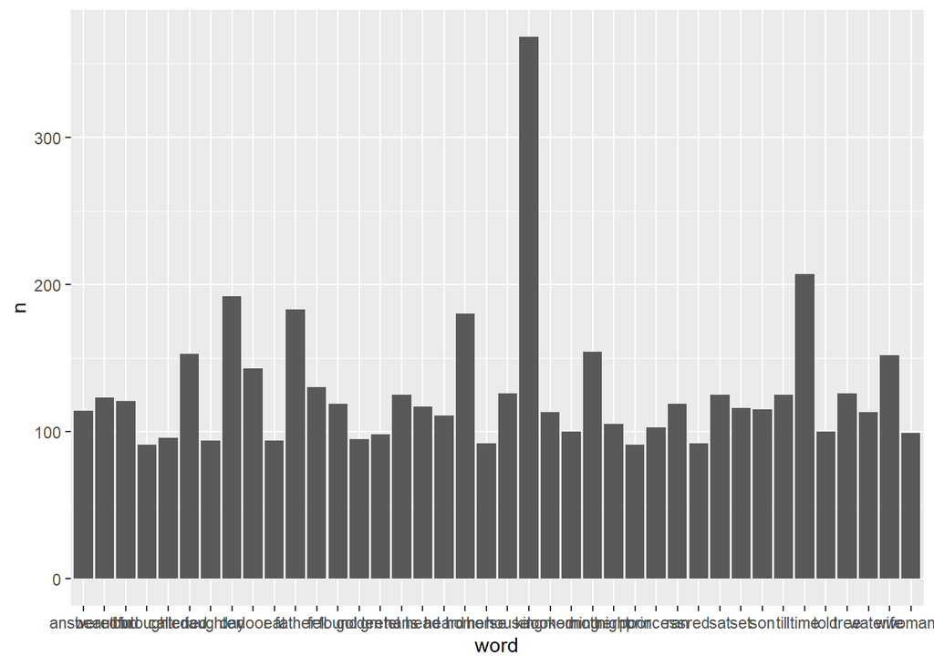

```r
fairytales_freq %>%
  filter(n>90 & gutenberg_id == "Grimm's Fairytales") %>%
  ggplot(aes(x=word, y=n)) +
  geom_col()
```

More elaborate graph:

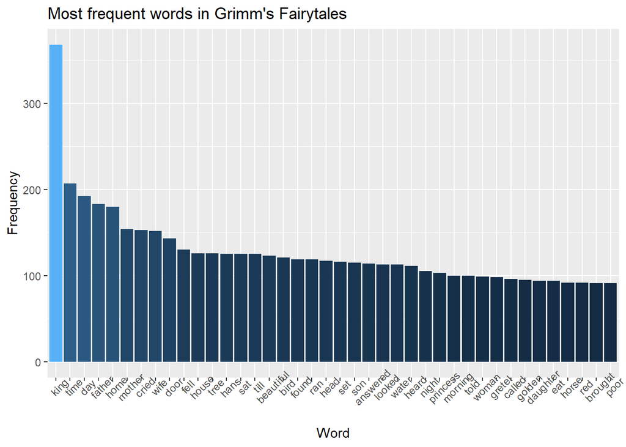

```r
fairytales_freq %>%
  filter(n>90 & gutenberg_id == "Grimm's Fairytales") %>%
  ggplot(aes(x=reorder(word, -n), y=n, fill=n)) + # descending order
  geom_col(show.legend=FALSE) +
  theme(axis.text.x = element_text(angle = 45)) + # readable labels
  xlab("Word") +
  ylab("Frequency") +
  ggtitle("Most frequent words in Grimm's Fairytales")
```

Or: flip coordinate system to make more space for words

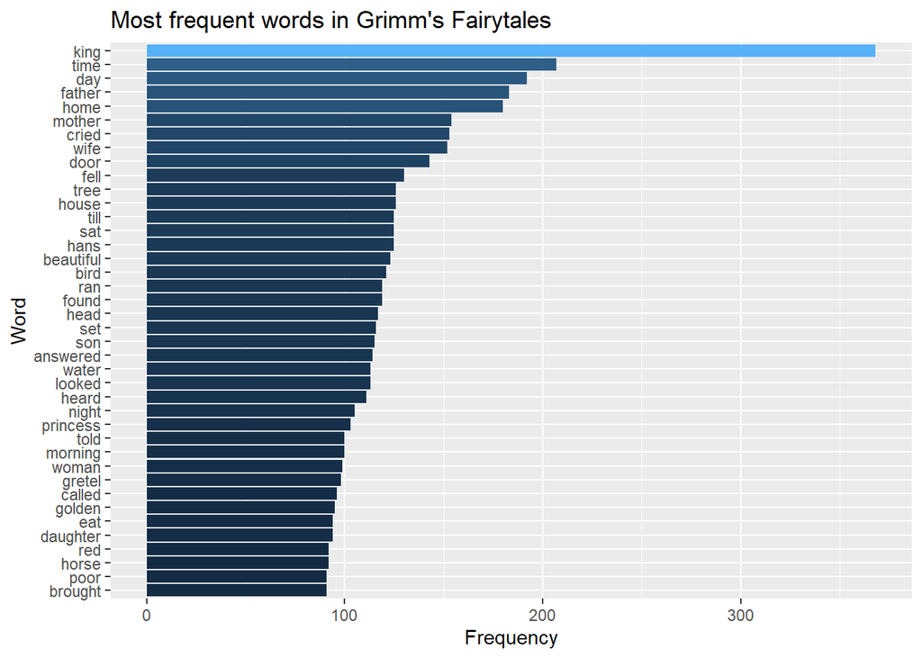

```r
fairytales_freq %>%
  filter(n>90 & gutenberg_id == "Grimm's Fairytales") %>%
  ggplot(aes(x=reorder(word, n), y=n, fill=n)) +
  geom_col(show.legend=FALSE) +
  xlab("Word") +
  ylab("Frequency") +
  ggtitle("Most frequent words in Grimm's Fairytales") +
  coord_flip()
```

### 3.2 Normalised frequency

- when comparing the frequencies of words from different texts, they are commonly normalised
- convention in corpus linguistics: report the frequency per 1 million words
- for shorter texts: per 10,000 or per 100,000 words
- calculation: raw frequency * 1,000,000 / total numbers in text

```r
# see the total number of words per play (doc_id)
shakes_freq %>%
  group_by(doc_id) %>%
  mutate(sum(n)) %>%
  distinct(doc_id, sum(n))
```

```
## # A tibble: 13 x 2
## # Groups:   doc_id [13]
##    doc_id             `sum(n)`
##    <chr>                 <int>
##  1 Hamlet                32049
##  2 Henry V               26967
##  3 King Richard III      31690
##  4 Tempest               21717
##  5 Othello               27488
##  6 King Lear             28015
##  7 Merchant of Venice    22015
##  8 Shrew                 22665
##  9 Romeo and Juliet      25959
## 10 As You Like It        23089
## 11 Julius Caesar         21044
## 12 Macbeth               17825
## 13 Midsummer             17090
```

```r
shakes_freq <- shakes_freq %>%
  na.omit() %>%
  group_by(doc_id) %>%
  mutate(pmw = n*1000000/sum(n)) %>% # creates a new column called pmw
  ungroup() %>%
  anti_join(stop_words) # removing stopwords afterwards
shakes_freq %>% select(word, pmw)
```

```
## # A tibble: 44,244 x 2
##    word        pmw
##    <chr>     <dbl>
##  1 brutus   17168.
##  2 ham      11187.
##  3 iago     12410.
##  4 romeo    11420.
##  5 thou     10648.
##  6 rosalind 11399.
##  7 king      8216.
##  8 king      9271.
##  9 lord      7395.
## 10 caesar   10985.
## # ... with 44,234 more rows
```

#### Plotting normalised frequency

Now we can plot, for example, the 20 most frequent words (by pmw).

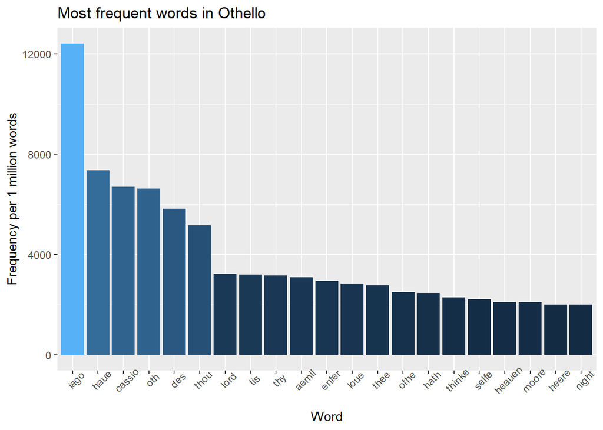

```r
shakes_freq %>%
  filter(doc_id == "Othello") %>%
  top_n(20, pmw) %>%
  ggplot(aes(x=reorder(word, -pmw), y=pmw, fill=pmw)) +
  geom_col(show.legend=FALSE) +
  theme(axis.text.x = element_text(angle = 45)) +
  xlab("Word") +
  ylab("Frequency per 1 million words") +
  ggtitle("Most frequent words in Othello")
```

## 4 Comparing the vocabulary of texts

Next, we’ll create two graphs to compare the vocabulary of our texts. First, we focus on Alice’s Adventures and Anderson’s Fairytales. The newly created comp_2 data frame contains only the words and their frequencies in the two texts in two separate columns.

### Comparing two texts

```r
comp_2 <- fairytales_freq %>%
  filter(gutenberg_id == "Alice's Adventures in Wonderland"|gutenberg_id == "Hans Christian Anderson's Fairytales") %>%
  group_by(gutenberg_id) %>%
  mutate(proportion = n / sum(n)) %>% #creates proportion column (word frequency divided by overall frequency per author)
  select(-n) %>%
  spread(gutenberg_id, proportion)
head(comp_2)
```

```
## # A tibble: 6 x 3
##   word      `Alice's Adventures in Wonderla~ `Hans Christian Anderson's Fairyta~
##   <chr>                                <dbl>                               <dbl>
## 1 abandoned                        NA                                  0.0000575
## 2 abashed                          NA                                  0.000172
## 3 abide                             0.000127                          NA
## 4 abode                            NA                                  0.0000575
## 5 abroad                           NA                                  0.000115
## 6 absalon                          NA                                  0.0000575
```

Now, we can plot the words. Their placement depends on the word frequencies. Additionally, colour coding shows how different the frequencies are - darker items are more similar in terms of their frequencies, lighter-coloured ones more frequent in one text compared to the other. We’ll discuss the interpretation in more detail once we’ve created the threeway comparison.

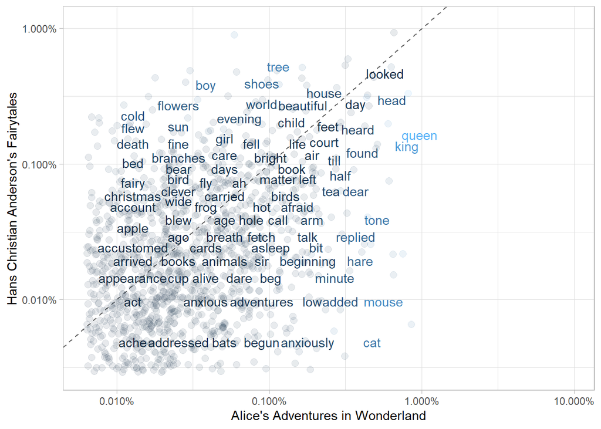

```r
ggplot(comp_2,
       aes(x = `Alice's Adventures in Wonderland`, y = `Hans Christian Anderson's Fairytales`,
           color = abs(`Alice's Adventures in Wonderland` - `Hans Christian Anderson's Fairytales`))) +
  geom_abline(color = "gray40", lty = 2) +
  geom_jitter(alpha = 0.1, size = 2.5, width = 0.3, height = 0.3) +
  geom_text(aes(label = word), check_overlap = TRUE, vjust = 1.5) +
  scale_x_log10(labels = percent_format()) +
  scale_y_log10(labels = percent_format()) +
  theme_light() +
  theme(legend.position="none") +
  labs(y = "Hans Christian Anderson's Fairytales", x = "Alice's Adventures in Wonderland")
```

### Comparing three texts

In order to compare three texts, we need to add one step to the data preparation: Grimm’s Fairytales will be the text that the other two will be compared to, so its word frequencies will be contained in the Grimm’s Fairytales column. The gutenberg_id column contains both Alice’s Adventures and Anderson’s Fairytales so we can pass this column to the facet_wrap command and create two graphs.

```r
comp_3 <- fairytales_freq %>%
  group_by(gutenberg_id) %>%
  mutate(proportion = n / sum(n)) %>% #creates proportion column (word frequency divided by overall frequency per author)
  select(-n) %>%
  spread(gutenberg_id, proportion) %>%
  gather(gutenberg_id, proportion, "Alice's Adventures in Wonderland":"Hans Christian Anderson's Fairytales") # only done for plotting
head(comp_3); unique(comp_3$gutenberg_id)
```

```
## # A tibble: 6 x 4
##   word      `Grimm's Fairytales` gutenberg_id                     proportion
##   <chr>                    <dbl> <chr>                                 <dbl>
## 1 abandoned           NA         Alice's Adventures in Wonderland  NA
## 2 abashed              0.0000342 Alice's Adventures in Wonderland  NA
## 3 abide                0.0000683 Alice's Adventures in Wonderland   0.000127
## 4 abode                0.0000683 Alice's Adventures in Wonderland  NA
## 5 abroad              NA         Alice's Adventures in Wonderland  NA
## 6 absalon             NA         Alice's Adventures in Wonderland  NA
```

```
## [1] "Alice's Adventures in Wonderland"
## [2] "Hans Christian Anderson's Fairytales"
```

The ggplot command is very similar to the one used above but facet_wrap is added to create two comparisons - Grimm’s Fairytales compared to Alice’s Adventures (left graph) and Grimm’s compared to Anderson’s fairytales (right graph):

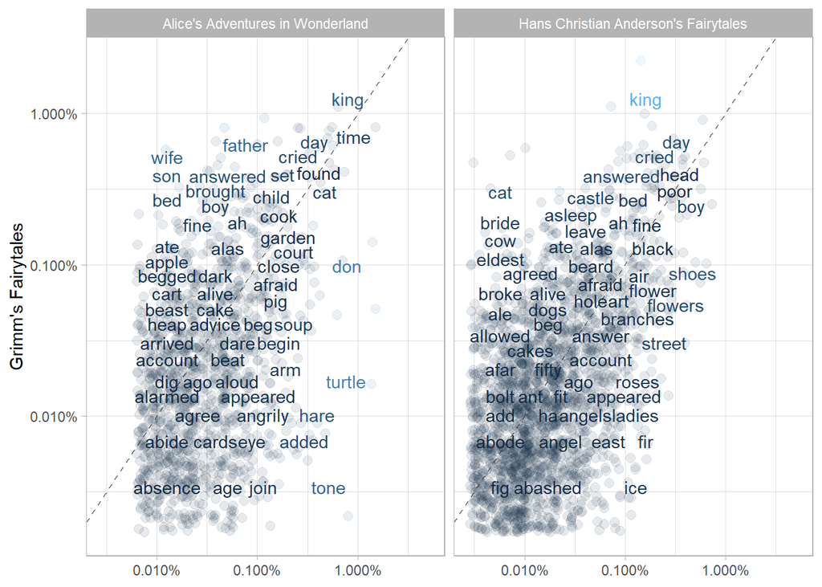

```r
ggplot(comp_3,
       aes(x = proportion, y = `Grimm's Fairytales`,
           color = abs(`Grimm's Fairytales` - proportion))) +
  geom_abline(color = "gray40", lty = 2) +
  geom_jitter(alpha = 0.1, size = 2.5, width = 0.3, height = 0.3) +
  geom_text(aes(label = word), check_overlap = TRUE) +
  scale_x_log10(labels = percent_format()) +
  scale_y_log10(labels = percent_format()) +
  theme_light() +
  facet_wrap(~ gutenberg_id, ncol = 2) +
  theme(legend.position="none") +
  labs(y = "Grimm's Fairytales", x = NULL)
```

### Interpretation

Words that are close to the diagonal line have similar frequencies in both texts (e.g. king, cook, calling in the left graph). Words that are far from the line are more frequent in one of the two texts (e.g. wife or son are more frequent for Grimm compared to Alice, while turtle and hare are more frequent in Alice than in Grimm). Again, this is also indicated by the colour.  
Generally, if the words are closer to the line and there’s a smaller gap for low frequencies, the vocabulary of the texts overall is more similar. In our case, the two fairytale sources contain more of the same words than Grimm compared to Alice.  
An additional step in an analysis of word frequencies and something we won’t cover today is to calculate correlations of word frequencies to quantify how similar the vocabularies of texts are.

## 5 Word and document frequencies

### tf-idf

How can we quantify what a text/document is about? We could analyse the term frequency (tf) - how often does a term occur in a text/document. However, common words are the same in most texts, e.g. grammatical words like articles. A solution would be to instead analyse the inverse document frequency (idf) which lowers the importance of frequent words and raises the importance of rare words in documents. So it’s a measure of how important a word is to a text compared to how important it is in the collection of texts.

#### The bind_tf_idf-function

- input: format needs to be one row per token (term), per document
- one column (here: word) contains the terms/tokens
- one column (here: gutenberg_id) contains the documents

```r
fairytales_idf <- fairytales_freq %>%
  bind_tf_idf(word, gutenberg_id, n)
fairytales_idf %>%
  select(gutenberg_id, word, tf_idf) %>%
  arrange(desc(tf_idf))
```

```
## # A tibble: 11,096 x 3
## # Groups:   gutenberg_id [3]
##    gutenberg_id                         word      tf_idf
##    <fct>                                <chr>      <dbl>
##  1 Alice's Adventures in Wonderland     alice    0.0559
##  2 Alice's Adventures in Wonderland     mock     0.00798
##  3 Alice's Adventures in Wonderland     hatter   0.00784
##  4 Alice's Adventures in Wonderland     gryphon  0.00770
##  5 Alice's Adventures in Wonderland     rabbit   0.00742
##  6 Hans Christian Anderson's Fairytales gerda    0.00720
##  7 Alice's Adventures in Wonderland     duchess  0.00588
##  8 Alice's Adventures in Wonderland     dormouse 0.00560
##  9 Hans Christian Anderson's Fairytales shadow   0.00537
## 10 Hans Christian Anderson's Fairytales kay      0.00454
## # ... with 11,086 more rows
```

**interpretation:** - low tf_idf if words appear in many books, high if they occur in few books  
- characteristic words for documents  
- so unsurprisingly, in our data, the first hits with the highest tf_idf are character names

#### Characteristic words per book

visualisation of the top 20 tf-idf words per book:

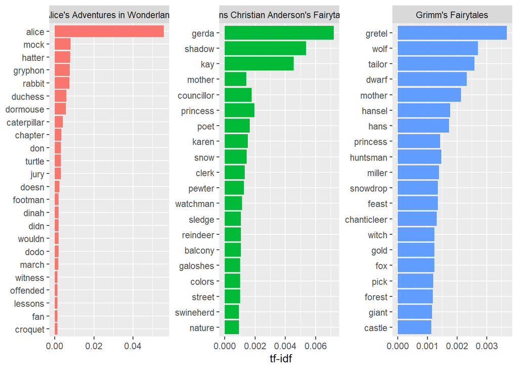

```r
fairytales_idf$word <- as.factor(fairytales_idf$word)
fairytales_idf %>%
  group_by(gutenberg_id) %>%
  arrange(desc(tf_idf)) %>%
  top_n(20, tf_idf) %>%
  ggplot(aes(x = reorder(word, tf_idf), y = tf_idf, fill = gutenberg_id)) +
  geom_col(show.legend = FALSE) +
  labs(x = NULL, y = "tf-idf") +
  facet_wrap(~gutenberg_id, scales = "free") +
  coord_flip()
```

#### Characteristic words per chapter

tf_idf can also be used to find characteristic words per chapter, or any other text unit. We’ll only use “Alice in Wonderland” as an example since it consists of several chapters.  
We first need to create a column that contains the chapter the word came from. The code below: - finds “chapter” followed by a Roman numeral by using a regular expression regex(“^chapter [\divclx]” in the str_detect() command  
- extracts the chapter number by counting how often this regex is found with cumsum(). This is basically a counter that starts at 0 if the regex isn’t matched, then counts up by one every time chapter + Roman numeral is found in the text  
- write it to a new column called “chapter”  
- also preserves the original line numbers (optional)  
We then remove the gutenberg_id column, words from chapter 0, i.e. the title and information on the edition, unnest tokens, and remove stopwords.

```r
alice <- fairytales_raw %>%
  filter(gutenberg_id == "Alice's Adventures in Wonderland") %>%
  mutate(linenumber = row_number(),
         chapter = cumsum(str_detect(text, regex("^chapter [\\divclx][^\\s]",
                                                 ignore_case = TRUE)))) %>%
  select(-gutenberg_id) %>%
  filter(chapter != 0) %>%
  mutate(chapter = as_factor(chapter)) %>%
  unnest_tokens(word, text) %>%
  anti_join(stop_words)
head(alice); summary(alice$chapter)
```

```
## # A tibble: 6 x 3
##   linenumber chapter word
##        <int> <fct>   <chr>
## 1         30 1       chapter
## 2         31 1       rabbit
## 3         31 1       hole
## 4         34 1       alice
## 5         34 1       beginning
## 6         34 1       tired
```

```
##   1   2   3   4   5   6   7   8   9  10  11  12
## 616 638 538 813 648 789 747 774 751 729 635 699
```

Now let’s calculate the tf-idf per chapter: - first step is to calculate the frequency for each word per chapter - then apply bind_tf_idf function - show words with the highest tf_idf

```r
alice <- alice %>%
  group_by(chapter) %>%
  count(word, sort = TRUE)

alice_idf <- alice %>%
  bind_tf_idf(word, chapter, n)

alice_idf %>%
  select(chapter, word, tf_idf) %>%
  arrange(desc(tf_idf))
```

```
## # A tibble: 4,733 x 3
## # Groups:   chapter [12]
##    chapter word        tf_idf
##    <fct>   <chr>        <dbl>
##  1 7       dormouse    0.0624
##  2 7       hatter      0.0594
##  3 5       caterpillar 0.0535
##  4 10      mock        0.0532
##  5 10      turtle      0.0532
##  6 9       turtle      0.0498
##  7 9       mock        0.0480
##  8 10      gryphon     0.0467
##  9 5       pigeon      0.0460
## 10 11      hatter      0.0458
## # ... with 4,723 more rows
```

Again, we can visualise the most characteristic words, this time per chapter:

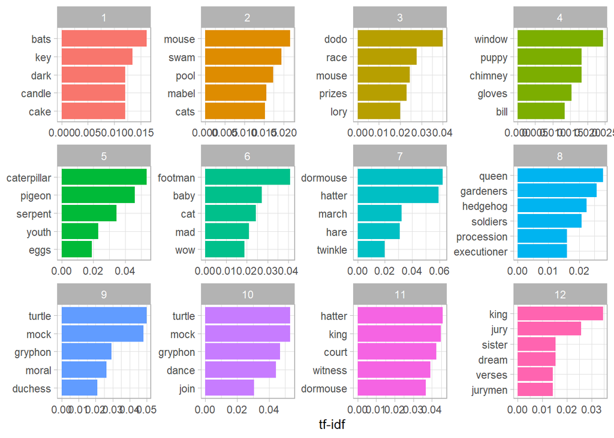

```r
alice_idf %>%
  group_by(chapter) %>%
  arrange(desc(tf_idf)) %>%
  top_n(5, tf_idf) %>%
  ungroup() %>%
  mutate(word = as_factor(word),
         word = reorder_within(word, tf_idf, chapter)) %>%
  ggplot(aes(word, tf_idf, fill = chapter)) +
  geom_col(show.legend = FALSE) +
  theme_light() +
  labs(x = NULL, y = "tf-idf") +
  facet_wrap(~ chapter, scales = "free") +
  scale_x_reordered() +
  coord_flip()
```

# Sentiment analysis

## 1 Sentiment analysis based on single words

### 1.1 Animal Crossing Data

Tidy Tuesday Week 19: https://github.com/rfordatascience/tidytuesday/blob/master/data/2020/2020-05-05/readme.md

Animal Crossing is a 2020 “sandbox” game, where your character lives on an island with a variety of different animal characters and collects resources to progress and upgrade the island. It has had mixed reviews: either it is the best game ever, or boring and pointless. It has also been criticized for the fact that you can only have one save game per console (“forcing” families/couples to buy extra consoles to avoid fights over island decor..)

“user_reviews” includes the date of a review posting, the user_name of the writer, the grade they give the game (0-10), and the text they wrote.

```r
user_reviews_raw <- readr::read_tsv('https://raw.githubusercontent.com/rfordatascience/tidytuesday/master/data/2020/2020-05-05/user_reviews.tsv') #download from tidytuesday github
head(user_reviews_raw)
```

```
## # A tibble: 6 x 4
##   grade user_name   text                                              date
##   <dbl> <chr>       <chr>                                             <date>
## 1     4 mds27272    My gf started playing before me. No option to cr~ 2020-03-20
## 2     5 lolo2178    While the game itself is great, really relaxing ~ 2020-03-20
## 3     0 Roachant    My wife and I were looking forward to playing th~ 2020-03-20
## 4     0 Houndf      We need equal values and opportunities for all p~ 2020-03-20
## 5     0 ProfessorF~ BEWARE!  If you have multiple people in your hou~ 2020-03-20
## 6     0 tb726       The limitation of one island per Switch (not per~ 2020-03-20
```

### 1.2 Preprocessing

- tokenisation: unnest_tokens
- remove stop words
  - not really necessary to remove all stop words for sentiment analysis – if a word has no emotional/sentiment-based meaning, it will just receive no score. But can be useful for misclassified words.

```r
more_stop_words <- tibble(word = c("nintendo", "switch"))

user_reviews <- user_reviews_raw %>%
  unnest_tokens(word, text) %>%
  anti_join(more_stop_words)
head(user_reviews)
```

```
## # A tibble: 6 x 4
##   grade user_name date       word
##   <dbl> <chr>     <date>     <chr>
## 1     4 mds27272  2020-03-20 my
## 2     4 mds27272  2020-03-20 gf
## 3     4 mds27272  2020-03-20 started
## 4     4 mds27272  2020-03-20 playing
## 5     4 mds27272  2020-03-20 before
## 6     4 mds27272  2020-03-20 me
```

### 1.3 Adding sentiment scores

- Assigns each word a score or a value based on entries in a pre-defined dictionary – then adds up all the scores to get a score per textual unit
- Dictionaries created by crowd-sourcing (Amazon Mechanical Turk, Twitter data) and/or by work on parts of the author(s) in collecting and analyzing the words
- Major disadvantage: what if the text includes the phrase “not good”? Word-based scores will just see “good” and give a positive score!
- We’ll look at three different dicts, all included in the tidytext package:
- All dictionaries are called with get_sentiments()
- Then, join with inner_join (keeps all words that are in BOTH dataframes)
- And count or sum!

#### 1.3.1 bing

- Binary: positive/negative

```r
head(get_sentiments("bing"))
```

```
## # A tibble: 6 x 2
##   word       sentiment
##   <chr>      <chr>
## 1 2-faces    negative
## 2 abnormal   negative
## 3 abolish    negative
## 4 abominable negative
## 5 abominably negative
## 6 abominate  negative
```

Inner join to get a sentiment for each word:

```r
user_reviews %>%
  inner_join(get_sentiments("bing")) %>%
  head()
```

```
## # A tibble: 6 x 5
##   grade user_name date       word         sentiment
##   <dbl> <chr>     <date>     <chr>        <chr>
## 1     4 mds27272  2020-03-20 sucks        negative
## 2     4 mds27272  2020-03-20 miss         negative
## 3     4 mds27272  2020-03-20 terrible     negative
## 4     4 mds27272  2020-03-20 unacceptable negative
## 5     5 lolo2178  2020-03-20 great        positive
## 6     5 lolo2178  2020-03-20 gorgeous     positive
```

```r
user_reviews %>%
  inner_join(get_sentiments("bing"))%>%
  count(sentiment)
```

```
## # A tibble: 2 x 2
##   sentiment     n
##   <chr>     <int>
## 1 negative  11097
## 2 positive  12825
```

Most common positive/negative words? Count by word and sentiment

```r
user_reviews %>%
  inner_join(get_sentiments("bing")) %>%
  count(word, sentiment, sort = TRUE) %>%
  head()
```

```
## # A tibble: 6 x 3
##   word     sentiment     n
##   <chr>    <chr>     <int>
## 1 like     positive   1357
## 2 fun      positive    760
## 3 great    positive    661
## 4 progress positive    556
## 5 good     positive    486
## 6 enjoy    positive    405
```

Each reviewer’s sentiment score: Note - we count “grade” so that this column isn’t dropped, since we want to compare to it later

```r
(user_sentiments_bing <- user_reviews %>%
  inner_join(get_sentiments("bing")) %>%
  count(user_name, grade, sentiment) %>%
  spread(sentiment, n, fill=0) %>%
  mutate(total_score = positive - negative))
```

```
## # A tibble: 2,783 x 5
##    user_name    grade negative positive total_score
##    <chr>        <dbl>    <dbl>    <dbl>       <dbl>
##  1 000anon2759      0        2        0          -2
##  2 11_11            0        5        6           1
##  3 12hwilso         0        1        2           1
##  4 1mooey          10        1        3           2
##  5 3nd3r02          2        4       13           9
##  6 425_Flex         0        8        3          -5
##  7 486eHyMy         0        0        2           2
##  8 4Plants         10        2        5           3
##  9 5DExperience     0        5       11           6
## 10 68Dube           4        3        0          -3
## # ... with 2,773 more rows
```

#### 1.3.2 AFINN

- Scale: -5 (very negative) to 5 (very positive)

```r
head(get_sentiments("afinn"))
```

```
## # A tibble: 6 x 2
##   word       value
##   <chr>      <dbl>
## 1 abandon       -2
## 2 abandoned     -2
## 3 abandons      -2
## 4 abducted      -2
## 5 abduction     -2
## 6 abductions    -2
```

Join to reviews and take a look

```r
user_reviews %>%
  inner_join(get_sentiments("afinn")) %>%
  head()
```

```
## # A tibble: 6 x 5
##   grade user_name date       word         value
##   <dbl> <chr>     <date>     <chr>        <dbl>
## 1     4 mds27272  2020-03-20 no              -1
## 2     4 mds27272  2020-03-20 sucks           -3
## 3     4 mds27272  2020-03-20 miss            -2
## 4     4 mds27272  2020-03-20 terrible        -3
## 5     4 mds27272  2020-03-20 unacceptable    -2
## 6     5 lolo2178  2020-03-20 great            3
```

Sum up one total per review (& save)

```r
(user_sentiments_afinn <- user_reviews %>%
  group_by(user_name, grade) %>% #retain grade for use later
  inner_join(get_sentiments("afinn")) %>%
  summarize(total_score = sum(value)) %>%
  ungroup())
```

```
## # A tibble: 2,843 x 3
##    user_name    grade total_score
##    <chr>        <dbl>       <dbl>
##  1 000anon2759      0          -7
##  2 000PLAYER000    10          -1
##  3 11_11            0          16
##  4 12hwilso         0           3
##  5 1mooey          10          10
##  6 24ths            0           1
##  7 3nd3r02          2          25
##  8 425_Flex         0         -11
##  9 486eHyMy         0           9
## 10 4Plants         10          12
## # ... with 2,833 more rows
```

What’s going on with the very negative sentiment scores for some positive reviews? Let’s join the text back to the sentiment scores and take a look:

```r
user_sentiments_afinn <- left_join(user_sentiments_afinn, user_reviews_raw)
user_sentiments_afinn %>%
  filter(grade > 8 & total_score < 0) %>%
  select(grade, total_score, text) %>%
  arrange(total_score)
```

```
## # A tibble: 92 x 3
##    grade total_score text
##    <dbl>       <dbl> <chr>
##  1    10         -17 STOP REVIEW BOMBING with fake WORDS 4SSH0L3SVengo siguiend~
##  2     9         -16 I'm going to start this review by saying Animal Crossing N~
##  3    10         -12 Most reviews here that are low, are review bombs due to th~
##  4    10         -11 I hate HATERS, i set 0 to all heaters! There is no anymore~
##  5    10         -10 Anyone rate bombing this game for one bad feature needs to~
##  6     9         -10 Eate videojuego es excelente en todos los sentidos. Pero c~
##  7    10          -9 Vraiment génial, c'est New Leaf en mieux ! Hâte de voir le~
##  8    10          -7 I dont think that one switch for one island is bad or good~
##  9    10          -7 Most of the negative reviews here are about console/island~
## 10    10          -7 Almost every negative review I have seen for this game add~
## # ... with 82 more rows
```

Reviews can use negative words when “defending” the game from other reviewers. Remember, it finds sentiments of words, regardless of negation and tone. (Some are also non-English… oops!)

Compare the two methods so far: This graph isn’t super helpful for this dataset (too many separate reviews) but is useful in other applications.

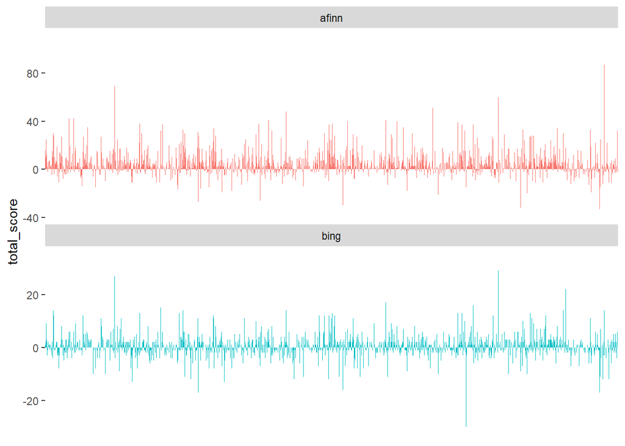

```r
user_sentiments_bing <- user_sentiments_bing %>%
  mutate(method="bing")
user_sentiments_afinn <- user_sentiments_afinn %>%
  mutate(method="afinn")
bind_rows(user_sentiments_bing,
          user_sentiments_afinn) %>%
  ggplot(aes(x = user_name, y = total_score, fill = method)) +
  geom_col(show.legend = FALSE) +
  facet_wrap(~method, ncol = 1, scales = "free_y") +
  theme(axis.title.x=element_blank(),
        axis.text.x=element_blank(),
        axis.ticks.x=element_blank())
```

#### 1.3.3 nrc

- Multiple emotions: positive, negative, anger, anticipation, disgust, fear, joy, sadness, surprise
- Scale: binary: either assigned the emotion or not

```r
head(get_sentiments("nrc"))
```

```
## # A tibble: 6 x 2
##   word      sentiment
##   <chr>     <chr>
## 1 abacus    trust
## 2 abandon   fear
## 3 abandon   negative
## 4 abandon   sadness
## 5 abandoned anger
## 6 abandoned fear
```

Join sentiment scores and count, checking out informative words:

```r
user_reviews %>%
  inner_join(get_sentiments("nrc")) %>%
  count(word, sentiment, sort = TRUE) %>%
  ungroup()
```

```
## # A tibble: 4,001 x 3
##    word     sentiment        n
##    <chr>    <chr>        <int>
##  1 player   negative      1844
##  2 console  positive      1489
##  3 console  sadness       1489
##  4 time     anticipation   960
##  5 fun      anticipation   760
##  6 fun      joy            760
##  7 fun      positive       760
##  8 progress anticipation   556
##  9 progress joy            556
## 10 progress positive       556
## # ... with 3,991 more rows
```

See: player, console – this would be a case for our custom stop words. Should be done at the beginning but let’s do it now:

```r
even_more_stop_words <- tibble(word = c("player", "console"))
user_reviews <- user_reviews %>%
  anti_join(even_more_stop_words)
user_reviews%>%
  inner_join(get_sentiments("nrc")) %>%
  count(word, sentiment, sort = TRUE) %>%
  ungroup()
```

```
## # A tibble: 3,998 x 3
##    word     sentiment        n
##    <chr>    <chr>        <int>
##  1 time     anticipation   960
##  2 fun      anticipation   760
##  3 fun      joy            760
##  4 fun      positive       760
##  5 progress anticipation   556
##  6 progress joy            556
##  7 progress positive       556
##  8 share    anticipation   500
##  9 share    joy            500
## 10 share    positive       500
## # ... with 3,988 more rows
```

Since these are binary categories, we again use count and spread:

```r
user_reviews %>%
  inner_join(get_sentiments("nrc")) %>%
  count(user_name, grade, sentiment, sort = TRUE)%>%
  spread(sentiment, n, fill=0)
```

```
## # A tibble: 2,782 x 12
##    user_name grade anger anticipation disgust  fear   joy negative positive
##    <chr>     <dbl> <dbl>        <dbl>   <dbl> <dbl> <dbl>    <dbl>    <dbl>
##  1 000anon2~     0     1            0       2     0     0        3        1
##  2 11_11         0     1            5       1     0     6        4        9
##  3 12hwilso      0     2            2       0     1     2        2        2
##  4 1mooey       10     0            2       0     0     2        1        2
##  5 24ths         0     0            1       0     0     1        0        1
##  6 3nd3r02       2     0            6       0     0     8        0       11
##  7 425_Flex      0     4            4       2     1     6        7        9
##  8 486eHyMy      0     0            3       0     0     1        1        1
##  9 4Plants      10     0            5       3     0     9        4       11
## 10 5DExperi~     0     1            6       0     2     7        6       12
## # ... with 2,772 more rows, and 3 more variables: sadness <dbl>,
## #   surprise <dbl>, trust <dbl>
```

Graph how many words of each sentiment show up by review grade: Note: Same code as above, without spread() and without counting by user_name

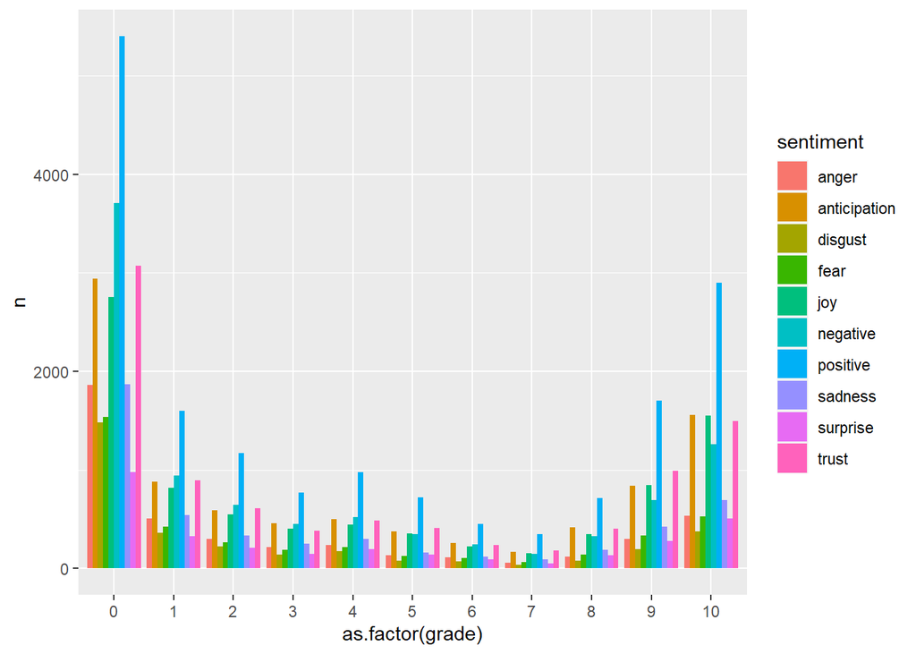

```r
user_reviews %>%
  inner_join(get_sentiments("nrc")) %>%
  count(grade, sentiment, sort = TRUE) %>%
  ggplot(aes(x=as.factor(grade), y=n, fill=sentiment)) +
  geom_col(position="dodge")
```

Reviews seem pretty polarized, let’s try to normalize them by total sentiments expressed

```r
user_reviews %>%
  inner_join(get_sentiments("nrc")) %>%
  count(grade, sentiment, sort = TRUE) %>%
  spread(sentiment, n, fill=0) %>%
  mutate(total = anger + anticipation + disgust + fear + joy + negative + positive + sadness + surprise + trust,
         anger = round(anger / total, 2),
         anticipation = round(anticipation / total, 2),
         disgust = round(disgust / total, 2),
         fear = round(fear / total, 2),
         joy = round(joy / total, 2),
         negative = round(negative / total, 2),
         positive = round(positive / total, 2),
         sadness = round(sadness / total, 2),
         surprise = round(surprise / total, 2),
         trust = round(trust / total, 2))
```

```
## # A tibble: 11 x 12
##    grade anger anticipation disgust  fear   joy negative positive sadness
##    <dbl> <dbl>        <dbl>   <dbl> <dbl> <dbl>    <dbl>    <dbl>   <dbl>
##  1     0  0.07         0.11    0.06  0.06  0.11     0.14     0.21    0.07
##  2     1  0.07         0.12    0.05  0.06  0.11     0.13     0.22    0.07
##  3     2  0.06         0.12    0.05  0.05  0.11     0.13     0.24    0.07
##  4     3  0.06         0.13    0.04  0.06  0.12     0.13     0.22    0.07
##  5     4  0.06         0.12    0.04  0.05  0.11     0.13     0.24    0.07
##  6     5  0.05         0.13    0.03  0.05  0.12     0.12     0.25    0.06
##  7     6  0.06         0.14    0.04  0.05  0.12     0.13     0.23    0.06
##  8     7  0.04         0.13    0.03  0.05  0.12     0.11     0.26    0.07
##  9     8  0.04         0.15    0.03  0.05  0.12     0.11     0.25    0.07
## 10     9  0.05         0.13    0.03  0.05  0.13     0.1      0.26    0.06
## 11    10  0.05         0.14    0.03  0.05  0.14     0.11     0.25    0.06
## # ... with 3 more variables: surprise <dbl>, trust <dbl>, total <dbl>
```

### 1.4 Recap: Word-based sentiment scores

- Three options for sentiment dictionaries by word (bing, afinn, nrc)
- Word-based sentiment analysis doesn’t consider negation, etc.
- Remove any incorrectly labeled or overly influential words with a custom stop word list
- Equalize scores based on number of words, reviews, sentiments
- Larger sample size = more likely to even out to 0
- Good for basic overview, but prone to many different types of errors – always look closely at your data, both as a summary table and plot!

### 1.5 Comparison clouds

Comparison clouds are extensions of word clouds. Instead of plotting the most frequent words in a text, with more frequent words in a bigger font, comparison clouds show word frequencies across documents. This means you can compare the vocabulary of texts, but we can also use it to look at the most frequent word per emotion, for example. The input format for a comparison cloud needs to be a matrix, with the words in rows and one document per column. We can use the acast function from reshape2 to achieve this format.

In the comparison.cloud call, we can specify arguments such as the colours, the maximum number of words that should be plotted, how many of them should be rotated, etc. See ?comparison.cloud for more details.

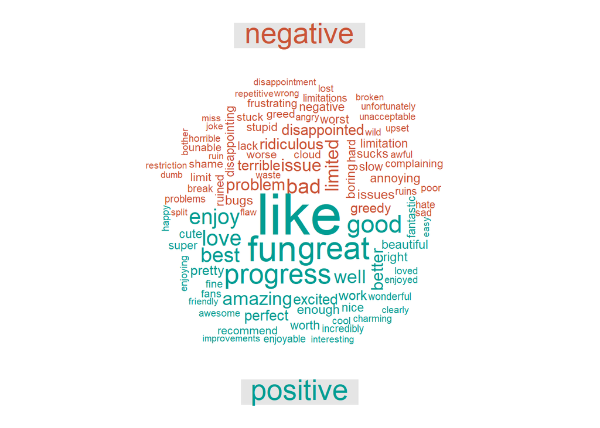

```r
user_reviews %>%
  inner_join(get_sentiments("bing")) %>%
  count(word, sentiment, sort = TRUE)%>%
  acast(word ~ sentiment, value.var = "n", fill = 0) %>%
  comparison.cloud(colors = c("#CA5336", "#009D93"),
                   max.words = 100,
                   title.size = 2, match.colors = TRUE)
```

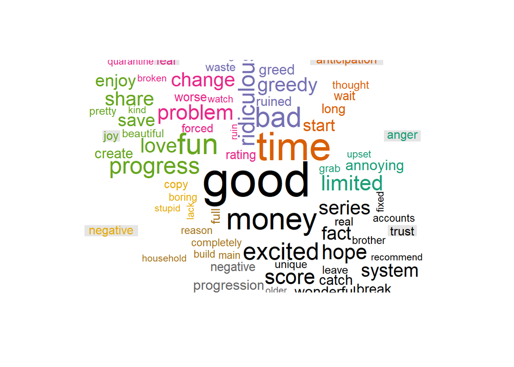

```r
user_reviews %>%
  inner_join(get_sentiments("nrc")) %>%
  count(word, sentiment, sort = TRUE) %>%
  acast(word ~ sentiment, value.var = "n", fill = 0) %>%
  comparison.cloud(max.words = 100,
                   title.size = 1, match.colors = TRUE)
```

For reference, here’s a wordcloud to visualise the most frequent words in the Shakespeare data. Here, the size indicates the frequency, with words that occur more often being displayed in a larger font size, but this can also be used to visualise e.g. normalised frequency (pmw) or length or anything else you pass to the freq = part of the command.

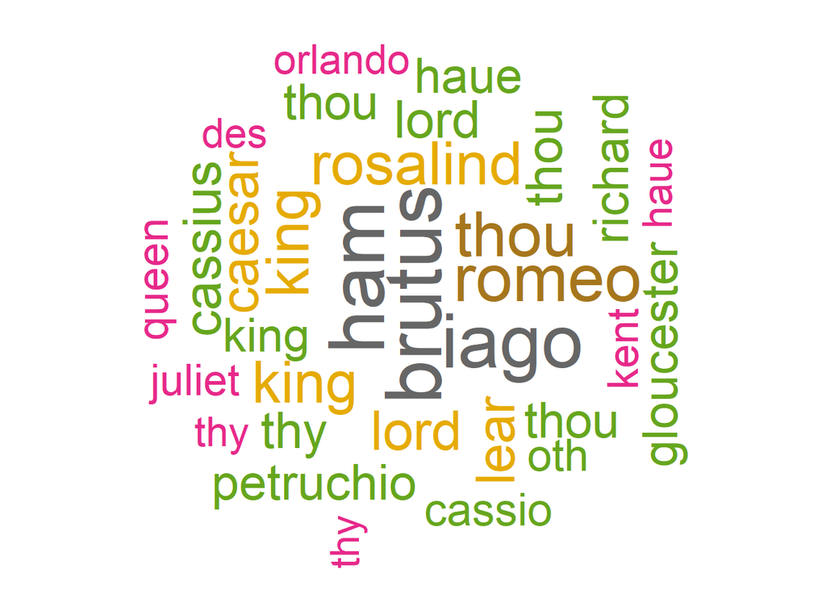

```r
wordcloud(words = shakes_freq$word, freq = shakes_freq$n,
          min.freq = 150, max.words=200, random.order=FALSE, rot.per=0.35,
          colors=brewer.pal(8, "Dark2"))
```

## 2 Sentiment analysis for sentences

So far, we’ve used a dictionary lookup to add sentiments for each individual word. This approach can run into problems. For example, “happy” would always receive a positive score, even though depending on the context (e.g. “not happy at all”) that might not be appropriate. Next, we’ll calculate sentiment scores by sentence, using the [sentimentr package](https://cran.r-project.org/web/packages/sentimentr/readme/README.html). This package also considers things like negation (“not happy”) and amplifiers (“really happy” is more positive than just “happy”) as well as deamplifiers (e.g. “barely”) and adversative conjunctions (e.g. “but”) when calculating sentiment scores.

You can run these lines of code to see the items that are considered negators, amplifiers, deamplifiers, and adversative conjunctions.

```r
lexicon::hash_valence_shifters[y==1] # negators
```

```
##             x y
##  1:     ain't 1
##  2:      aint 1
##  3:    aren't 1
##  4:     arent 1
##  5:     can't 1
##  6:    cannot 1
##  7:      cant 1
##  8:  couldn't 1
##  9:   couldnt 1
## 10:   daren't 1
## 11:    darent 1
## 12:    didn't 1
## 13:     didnt 1
## 14:   doesn't 1
```

[output cut: 39 more lines]

```r
lexicon::hash_valence_shifters[y==2] # amplifiers
```

```
##                 x y
##  1:    absolutely 2
##  2:         acute 2
##  3:       acutely 2
##  4:       certain 2
##  5:     certainly 2
##  6:      colossal 2
##  7:    colossally 2
##  8:  considerably 2
##  9:     decidedly 2
## 10:          deep 2
## 11:        deeply 2
## 12:      definite 2
## 13:    definitely 2
## 14:      enormous 2
```

[output cut: 44 more lines]

```r
lexicon::hash_valence_shifters[y==3] # deamplifiers
```

```
##                x y
##  1:       almost 3
##  2:       barely 3
##  3:      faintly 3
##  4:          few 3
##  5:       hardly 3
##  6:   incredibly 3
##  7:      kind of 3
##  8:        kinda 3
##  9:        least 3
## 10:       little 3
## 11:         only 3
## 12:       partly 3
## 13:       rarely 3
## 14:       seldom 3
## 15:     slightly 3
## 16:     somewhat 3
## 17:      sort of 3
## 18:        sorta 3
## 19:     sparsely 3
## 20: sporadically 3
## 21:     very few 3
## 22:  very little 3
##                x y
```

```r
lexicon::hash_valence_shifters[y==4] # adversative conjunctions
```

```
##                   x y
## 1:         although 4
## 2:              but 4
## 3: despite all that 4
## 4: despite all this 4
## 5:     despite that 4
## 6:     despite this 4
## 7:          however 4
## 8:  that being said 4
## 9:          whereas 4
```

Let’s look at a simple example to compare the two approaches:

```r
examples <- data.frame(
  id = c("1", "2"),
  text = c("I was very happy.", "She was not happy.")
)
sentiment(get_sentences(examples$text))
```

```
##    element_id sentence_id word_count sentiment
## 1:          1           1          4     0.675
## 2:          2           1          4    -0.375
```

```r
examples %>%
  unnest_tokens(word, text) %>%
  inner_join(get_sentiments("bing"))
```

```
##   id  word sentiment
## 1  1 happy  positive
## 2  2 happy  positive
```

### 2.1 Polarity

#### …by entire texts

First, we’ll calculate an average sentiment score for each of the texts (i.e. entire plays) in our Shakespeare data. *Be warned - since this is a lot of data, this will take a little while…*

```r
shakes_sentiments <- shakes %>%
    mutate(sents = get_sentences(text)) %$%
    sentiment_by(sents, doc_id)
```

##### Plotting

The first line of code creates a graph in which the plays are sorted alphabetically (because when we read in the data, the files were sorted alphabetically) while the second command sorts the plays from highest to lowest sentiment score (removing the - will sort from lowest to highest). We’re also adding labels.

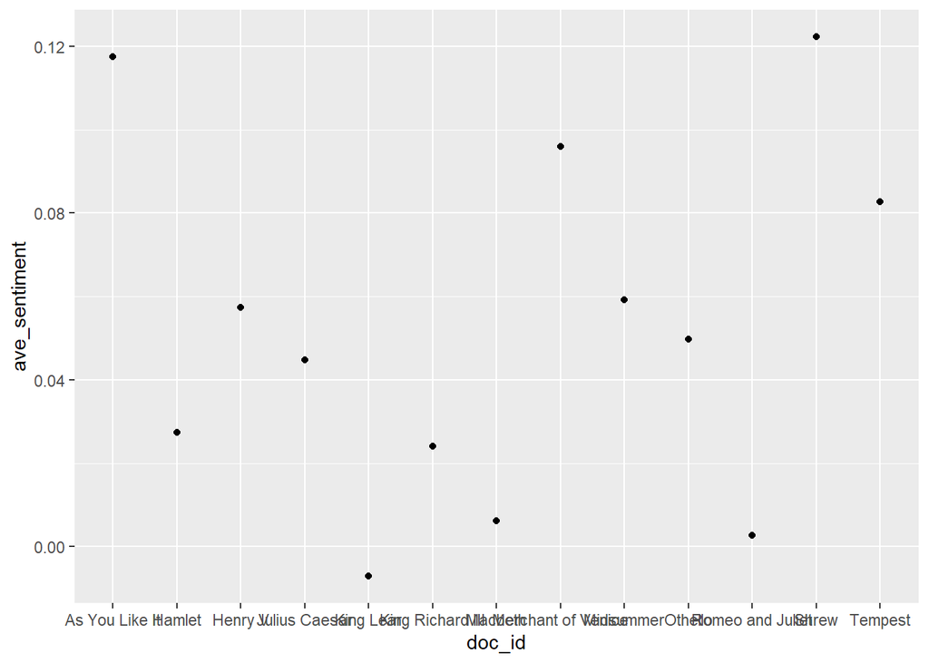

```r
ggplot(shakes_sentiments) +
  aes(x = doc_id, y = ave_sentiment) +
  geom_point()
```

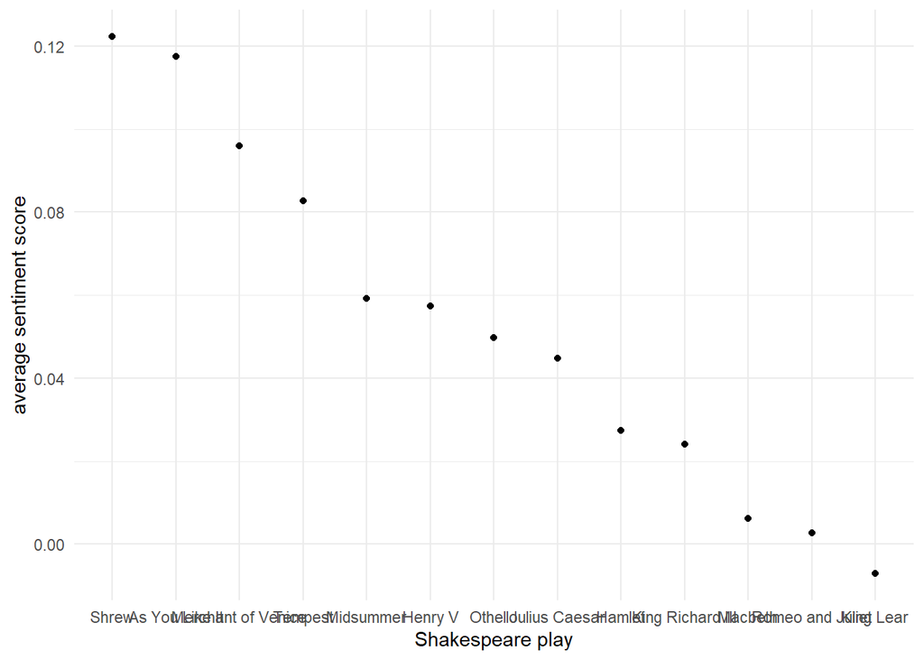

```r
ggplot(shakes_sentiments) +
  aes(x = reorder(doc_id, -ave_sentiment), y = ave_sentiment) +
  geom_point() +
  labs(x = "Shakespeare play", y = "average sentiment score") +
  theme_minimal()
```

Adding information on the kinds of plays and creating a lollipop plot:

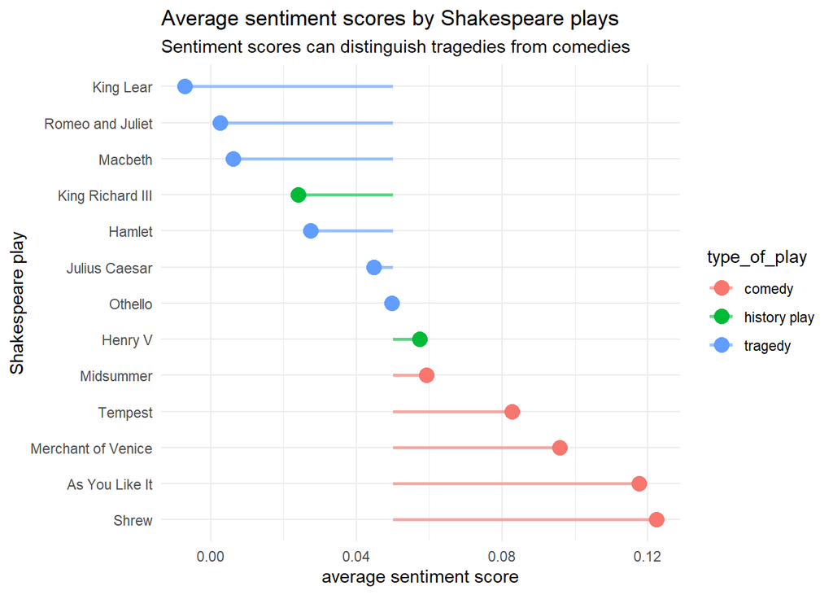

```r
shakes_sentiments <- shakes_sentiments %>%
  mutate(type_of_play = if_else(doc_id %in% c("Midsummer", "Tempest", "Merchant of Venice", "As You Like It", "Shrew"), "comedy",
                                if_else(doc_id %in% c("King Lear", "Romeo and Juliet", "Macbeth", "Hamlet", "Julius Caesar", "Othello"), "tragedy", "history play")))

ggplot(shakes_sentiments) +
  aes(x = reorder(doc_id, -ave_sentiment), y = ave_sentiment) +
  geom_point(aes(colour = type_of_play), size = 4) +
  geom_segment(aes(x = doc_id, xend = doc_id,
                   y = 0.05, yend = ave_sentiment,
                   colour = type_of_play),
               size = 1, alpha = 0.6) +
  theme_minimal() +
  coord_flip() +
  labs(x = "Shakespeare play",
       y = "average sentiment score",
       title = "Average sentiment scores by Shakespeare plays",
       subtitle = "Sentiment scores can distinguish tragedies from comedies")
```

So we can see that the sentiment scores accurately distinguish the comedies and tragedies, with the comedies receiving higher sentiment scores.

#### …by sentences

For this next part, we’ll once more use *Alice’s Adventures in Wonderland* downloaded from Project Gutenberg. As explained above, we use str_detect in combination with a regular expression to find “chapter” followed by a Roman numeral. The cumsum command counts up by one every time this regular expression is matched. We then remove the Gutenberg ID and “chapter 0” (i.e. the title and publisher).

```r
alice_raw <- gutenberg_download(11, mirror = "http://mirrors.xmission.com/gutenberg/")

alice <- alice_raw %>%
  mutate(chapter = cumsum(str_detect(text, regex("^chapter [\\divclx]", ignore_case = TRUE)))) %>%
  select(-gutenberg_id) %>%
  filter(chapter != 0)
alice$chapter <- as_factor(alice$chapter)
```

Since the gutenbergr package preserves the line structure of the original text, we need to first paste the lines to form a coherent text. Otherwise, the get_sentences function won’t work properly.

```r
alice <- alice %>%
  group_by(chapter) %>%
  summarise(text_complete = paste(text, collapse=" ")) %>%
  ungroup()
```

Let’s now get sentiment scores for each sentence:

```r
alice_sentences <- alice %>%
  get_sentences() %>%
  sentiment()
```

…plot their development throughout the text:

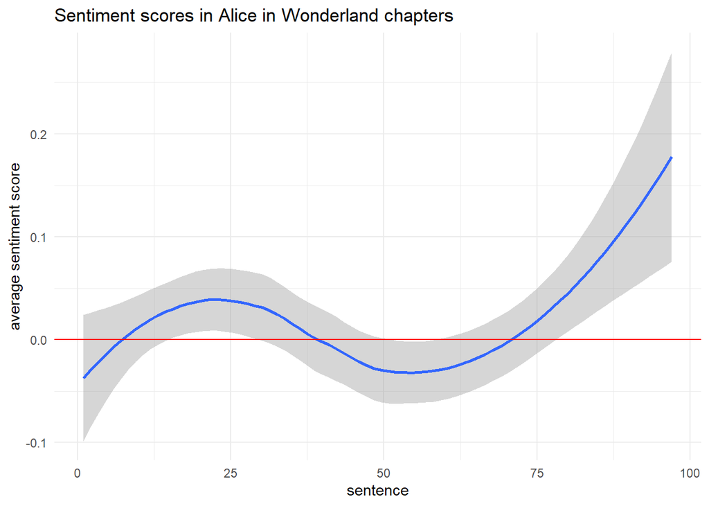

```r
ggplot(alice_sentences) +
  aes(sentence_id, sentiment) +
  geom_smooth() +
  geom_hline(yintercept=0, color = "red") +
  labs(x = "sentence", y = "average sentiment score",
       title = "Sentiment scores in Alice in Wonderland chapters") +
  theme_minimal()
```

…and plot their development per chapter:

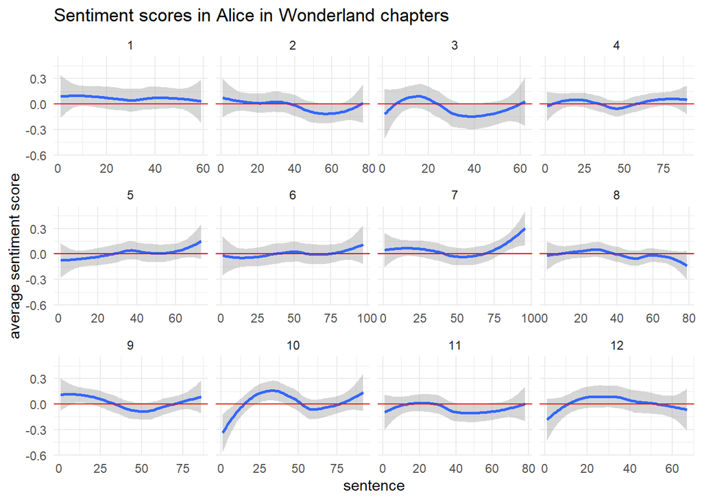

```r
ggplot(alice_sentences) +
  aes(sentence_id, sentiment) +
  geom_smooth() +
  facet_wrap(~chapter, scales = "free_x") +
  geom_hline(yintercept=0, color = "red") +
  labs(x = "sentence", y = "average sentiment score",
       title = "Sentiment scores in Alice in Wonderland chapters") +
  theme_minimal()
```

We could also use sentiment_by to get sentiment scores by chapter, but it’s often more flexible to work with the sentence scores and use group_by and summarise to calculate averages per chapter:

```r
alice_sentences %>%
  group_by(chapter) %>%
  summarise(sentiment_ch = mean(sentiment), sentiment_sd = sd(sentiment))
```

```
## # A tibble: 12 x 3
##    chapter sentiment_ch sentiment_sd
##    <fct>          <dbl>        <dbl>
##  1 1           0.0707          0.254
##  2 2          -0.0270          0.271
##  3 3          -0.0373          0.312
##  4 4           0.0238          0.221
##  5 5           0.00613         0.235
##  6 6           0.000312        0.299
##  7 7           0.0559          0.271
##  8 8          -0.00634         0.204
##  9 9           0.0232          0.246
## 10 10          0.0204          0.301
## 11 11         -0.0479          0.243
## 12 12          0.0157          0.277
```

Finally, let’s take a closer look at which sentences are more positive and which ones are more negative using highlight():

```r
alice %>%
  filter(chapter %in% c("1", "11")) %>%
  mutate(sents = get_sentences(text_complete)) %$%
    sentiment_by(sents, chapter) %>%
  highlight()
```

```
## Saved in C:\Users\Lenovo\AppData\Local\Temp\Rtmpei6X92/polarity.html
```

```
## Opening C:\Users\Lenovo\AppData\Local\Temp\Rtmpei6X92/polarity.html ...
```

### 2.2 Emotions

So far, we’ve focused on polarity (positive - negative) per sentences, but the sentimentr package also provides many other interesting functions. Here are some we won’t have time to go into today:  
- find and count instances of profanity - replace emojis and internet slang/abbreviations with their text equivalents - create your own sentiment dictionary

It’s also possible to calculate ratings for the detailed emotions we discussed before. Instead of sentiment(_by), we use emotion(_by), e.g.

```r
alice_emotions <- alice %>%
  get_sentences() %>%
  emotion()
head(alice_emotions, 16) %>% select(emotion_type, emotion_count, emotion)
```

```
##             emotion_type emotion_count emotion
##  1:                anger             0       0
##  2:        anger_negated             0       0
##  3:         anticipation             0       0
##  4: anticipation_negated             0       0
##  5:              disgust             0       0
##  6:      disgust_negated             0       0
##  7:                 fear             0       0
##  8:         fear_negated             0       0
##  9:                  joy             0       0
## 10:          joy_negated             0       0
## 11:              sadness             0       0
## 12:      sadness_negated             0       0
## 13:             surprise             0       0
## 14:     surprise_negated             0       0
## 15:                trust             0       0
## 16:        trust_negated             0       0
```

As an example, let’s plot “fear” and “sadness” throughout the chapters:

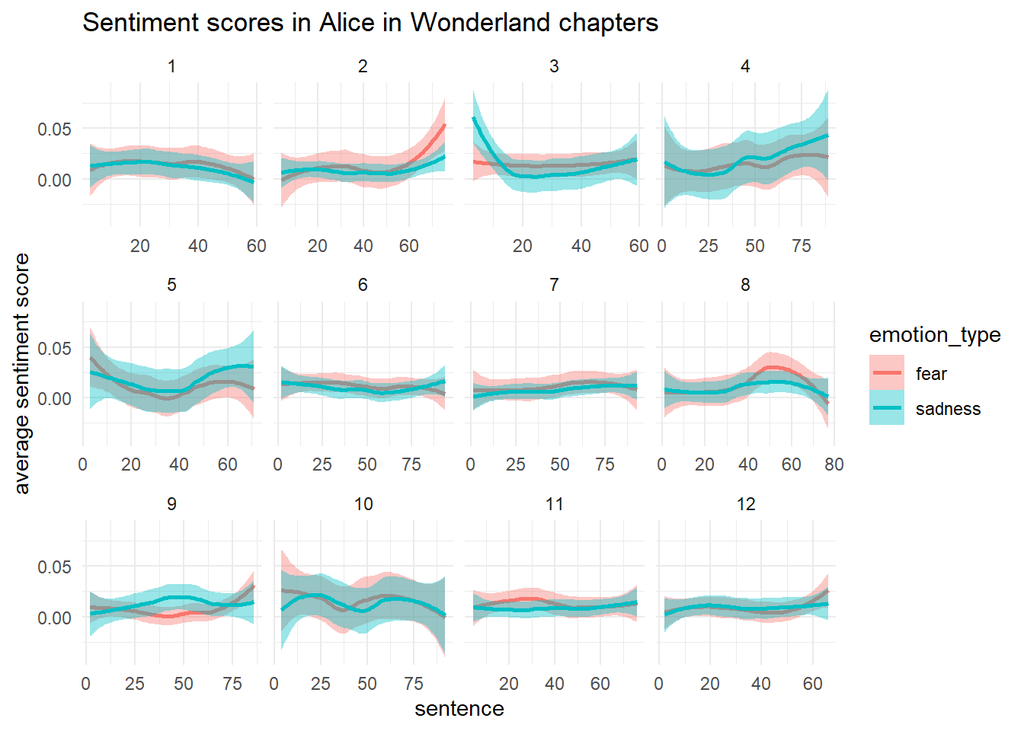

```r
alice_emotions %>%
  filter(emotion_type %in% c("fear", "sadness")) %>%
  ggplot() + aes(sentence_id, emotion, fill = emotion_type, colour = emotion_type) +
  geom_smooth() +
  facet_wrap(~chapter, scales = "free_x") +
  labs(x = "sentence", y = "average sentiment score",
       title = "Sentiment scores in Alice in Wonderland chapters") +
  theme_minimal()
```

## 3 Takeaway message

Keep in mind that no automated analysis can be perfect. Sentiment analysis has difficulties dealing with non-standard language such as informal spoken or historical registers. Always take a close look at your data! Thorough data cleaning and annotation (e.g. lemmatisation) can improve its accuracy.  
Further topics in the realm of text analysis we didn’t have time for today include: - part-of-speech tagging - n-grams - topic modeling - ….